# Data Analysis - The Global Diffusion of Work-Injury Insurance: The Role of Spatial Networks and Nation Building

### Treatment plot

Plot sequences centered at the formation of nation states

```r
# remove missing
treat_plot <- subset(treat_plot, formation != "Inf")
treat_plot$law_seq <- as.factor(as.character(treat_plot$law_seq, levels = c("1","2","3"), labels = c("None","Liability","Social Insurance")))

# order by formation
treat_plot <- treat_plot %>%
  mutate(order = ifelse(per == socins, formation, -1000),
         order = max(order, na.rm = T),
         order = ifelse(order == -1000, 1000, order))

treat_plot <- treat_plot[order(treat_plot$order),]

treat_plot <- treat_plot %>%
  ungroup() %>%
  mutate(n =  row_number())

treat_plot <- treat_plot %>%
  group_by(id) %>%
  mutate(n_id = max(n, na.rm =T)) %>%
  ungroup()


agg_png(filename = "results/Fig1.png", height = 600, width = 750, res = 144)
ggplot(treat_plot, aes(formation, rev(n_id), fill = law_seq)) +
  geom_tile() +
  scale_fill_manual(breaks = c("1", "2", "3"),
  values = c("grey25","chocolate4","seagreen4"),
  labels = c("None", "Employer Liability", "Social Insurance"),
  ) +
  ylab(label = "Country") +
  xlab(label = "Time in Years\n(centered by year of state formation)") +
  xlim(-25,75) +
  geom_vline(xintercept = -0.5, size = 1) +
  theme_classic() +
  theme(axis.text.y = element_blank(),
        axis.line = element_blank(),
        axis.ticks = element_blank(),
        legend.title = element_blank(),
        panel.background = element_rect(color = "grey", fill = "grey"))
dev.off()
```

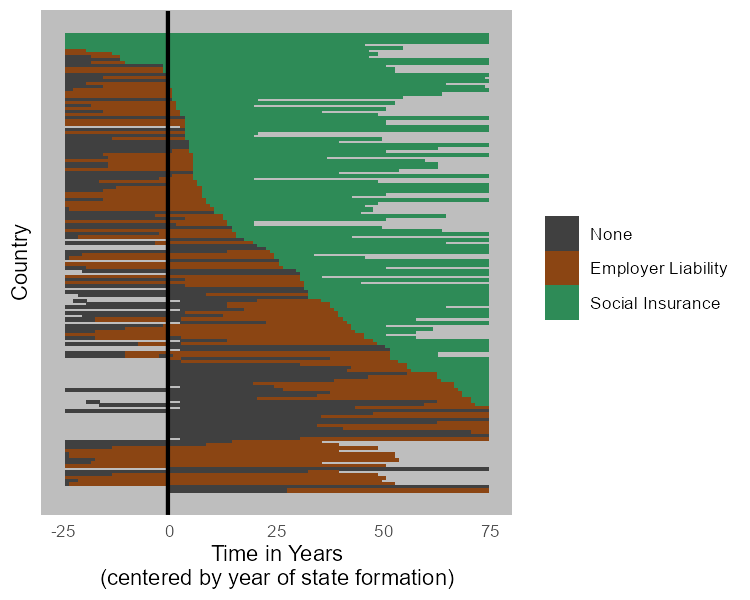

```r
knitr::include_graphics("results/Fig1.png", dpi = 36)
```

### Sesitivity Analysis

Including Agriculture instead of GDP. This still needs work as the period 1990 to 2010 seems to have mostly been interpolated and therefore, not of much use.

```r
model3_sens <- glm(adopted ~
              + t0_22
              + t23_48
              + t49_74
              + t75_99
              + t100_130
              + existence
              #+ lag_w_expo_culture
              #+ w_expo_colony
              + lag_w_expo_trade
              + lag_w_expo_proximity
              #+ ag_rel
              + regime
              + 0,
              dat    = diff_data,
              subset = (per <= toa),
              family = binomial(link="logit"))

model3_socins_sens <- glm(adopted ~
                + t0_22
              + t23_48
              + t49_74
              + t75_99
              + t100_130
              + existence
              #+ lag_w_expo_culture
              #+ w_expo_colony
              + lag_w_expo_trade
              + lag_w_expo_proximity
              + ag_rel
              + regime
              + 0,
              dat    = diff_data_socins,
              subset = (per <= toa),
              family = binomial(link="logit"))

stargazer(model3_sens,model3_socins_sens,
          type = "text",
          title = "Discrete Time Hazard/Diffusion Models of /nWork-Injury Law, 1880-2010 in 83 countries",
          dep.var.labels=c("First Work-Injury Social Insurance Law"),

          out="results/Tbl3_ag_sens.htm")
```

```
##
## Discrete Time Hazard/Diffusion Models of /nWork-Injury Law, 1880-2010 in 83 countries
## ============================================================
##                                Dependent variable:
##                      ---------------------------------------
##                      First Work-Injury Social Insurance Law
##                              (1)                 (2)
## ------------------------------------------------------------
## t0_22                     -5.834***           -5.604***
##                            (0.277)             (0.519)
##
## t23_48                    -5.027***           -5.100***
##                            (0.230)             (0.430)
##
## t49_74                    -5.931***           -4.744***
##                            (0.464)             (0.590)
##
## t75_99                    -6.553***           -5.430***
##                            (0.609)             (0.795)
##
## t100_130                  -6.601***           -6.183***
##                            (0.733)             (1.027)
##
## existence                  0.805***             0.473
##                            (0.296)             (0.423)
##
## lag_w_expo_trade            -0.133              0.806
##                            (0.231)             (0.692)
##
## lag_w_expo_proximity       4.477***             2.270*
##                            (0.750)             (1.288)
##
## ag_rel                                         -0.0003
##                                                (0.001)
##
## regime                     0.235***             0.087
##                            (0.051)             (0.056)
##
## ------------------------------------------------------------
## Observations                7,766               3,046
## Log Likelihood             -644.813            -283.448
## Akaike Inf. Crit.         1,307.625            586.896
## ============================================================
## Note:                            *p<0.1; **p<0.05; ***p<0.01
```

### Visualizations

Note that here it doesn’t matter which diffnet object we use, the underlying adoption data are identical

#### Hazard Rate by Start GDP plot

Create groups within the data. High/Low GDP in 1900 & 2000.

`mean(diff_data$gdp10000[diff_data$per == 1900], na.rm = T)` [1] 0.1851475 `mean(diff_data$gdp10000[diff_data$per == 2000], na.rm = T)` [1] 1.214281

```r
gdp_groups <- diff_data %>%
  select(gdp10000, lag_w_expo_proximity, id, per, adopted) %>%
  mutate(gdp_1900 = ifelse(gdp10000 <= 0.2 & per == 1900, 1, 0),
         gdp_2000 = ifelse(gdp10000 <= 1.4 & per == 2000, 1, 0),
         proximity = ifelse(lag_w_expo_proximity <= 0.5 & adopted == 1 & lag(adopted) == 0, 1, 0)) %>%
  group_by(id) %>%
  summarise(gdp1900 = max(gdp_1900, na.rm = T),
            gdp2000 = max(gdp_2000, na.rm = T),
            proxim = max(proximity, na.rm = T))

diff_data_gdp <- left_join(diff_data, gdp_groups, by = "id")
diff_data_socins_gdp <- left_join(diff_data_socins, gdp_groups, by = "id")

# remove NA
diff_data_gdp <- diff_data_gdp[!is.na(diff_data_gdp$adopted),]
diff_data_socins_gdp <- diff_data_socins_gdp[!is.na(diff_data_socins_gdp$adopted),]


# change to survival data, remove objects after adoption
 diff_data_gdp <- diff_data_gdp %>%
  group_by(id) %>%
  mutate(cut = adopted + lag(adopted),
         cut = ifelse(is.na(cut), 0, cut)) %>%
  subset(cut == 1) %>%
  ungroup()

 diff_data_socins_gdp <- diff_data_socins_gdp %>%
  group_by(id) %>%
  mutate(cut = adopted + lag(adopted),
         cut = ifelse(is.na(cut), 0, cut)) %>%
  subset(cut == 1) %>%
  ungroup()

# create Cox regression object
fit1 <- survfit(Surv(per, adopted) ~ gdp1900, data = diff_data_gdp)

fit3 <- survfit(Surv(per, adopted) ~ gdp1900, data = diff_data_socins_gdp)
```

```r
agg_png(filename = "results/Fig3_A.png", height = 600, width = 600, res = 144)

ggsurvplot(fit1, data = diff_data_gdp,
           fun = "event",
           conf.int = T,
           palette = "jco",
           xlim = c(1880,2010),
           break.time.by = 20,
           xlab = "Year",
           legend.labs = c("Start GDP High","Start GDP Low"),
           title = "First Law",
           ylab = "")
dev.off()
```

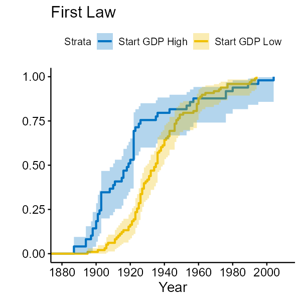

```r
knitr::include_graphics("results/Fig3_A.png", dpi = 48)
```

```r
agg_png(filename = "results/Fig3_B.png", height = 600, width = 600, res = 144)

ggsurvplot(fit3, data = diff_data_socins_gdp,
           fun = "event",
           conf.int = T,
           palette = "jco",
           xlim = c(1880,2010),
           break.time.by = 20,
           xlab = "Year",
           legend.labs = c("Start GDP High","Start GDP Low"),
           title = "First Social Insurance",
           ylab = "")
dev.off()
```

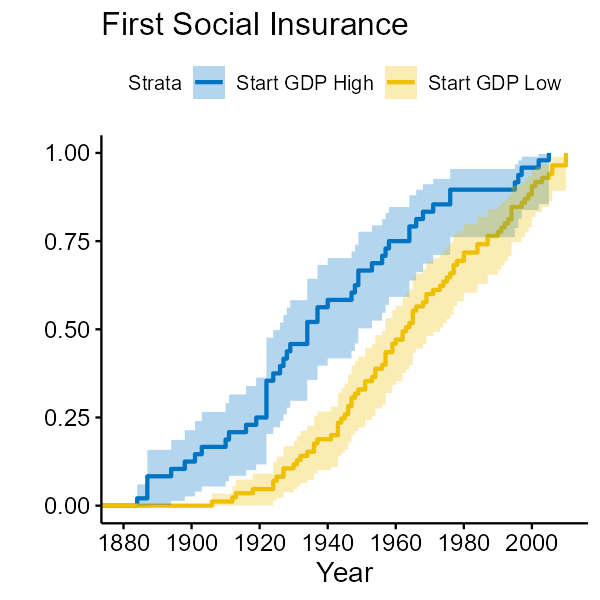

```r
knitr::include_graphics("results/Fig3_B.png", dpi = 48)
```

#### Alternative Adoption Plots

##### First Law

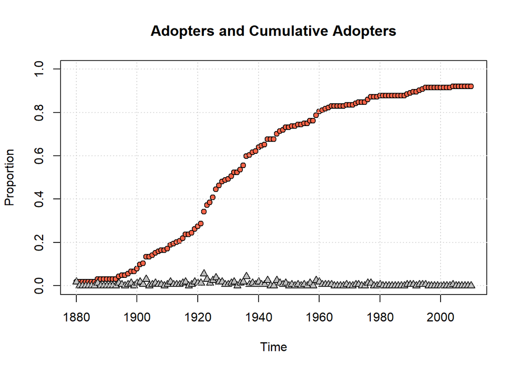

```r
plot_adopters(diffnet_proximity,
              include.legend = FALSE, what = c("adopt", "cumadopt"))
```

##### Social Insurance

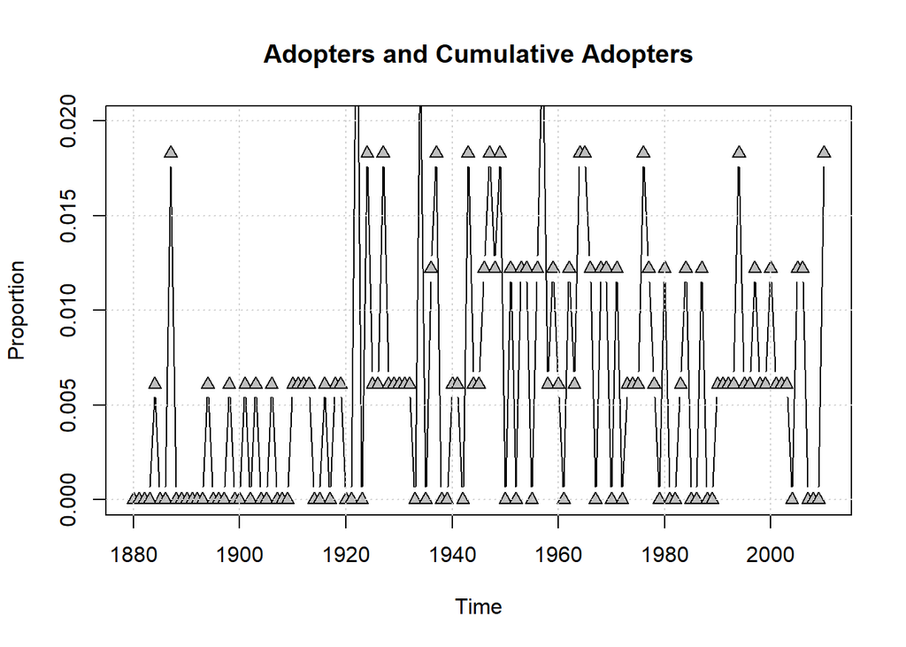

```r
plot_adopters(diffnet_proximity_socins,
              include.legend = FALSE, what = c("adopt"), ylim = c(0,0.02))
```

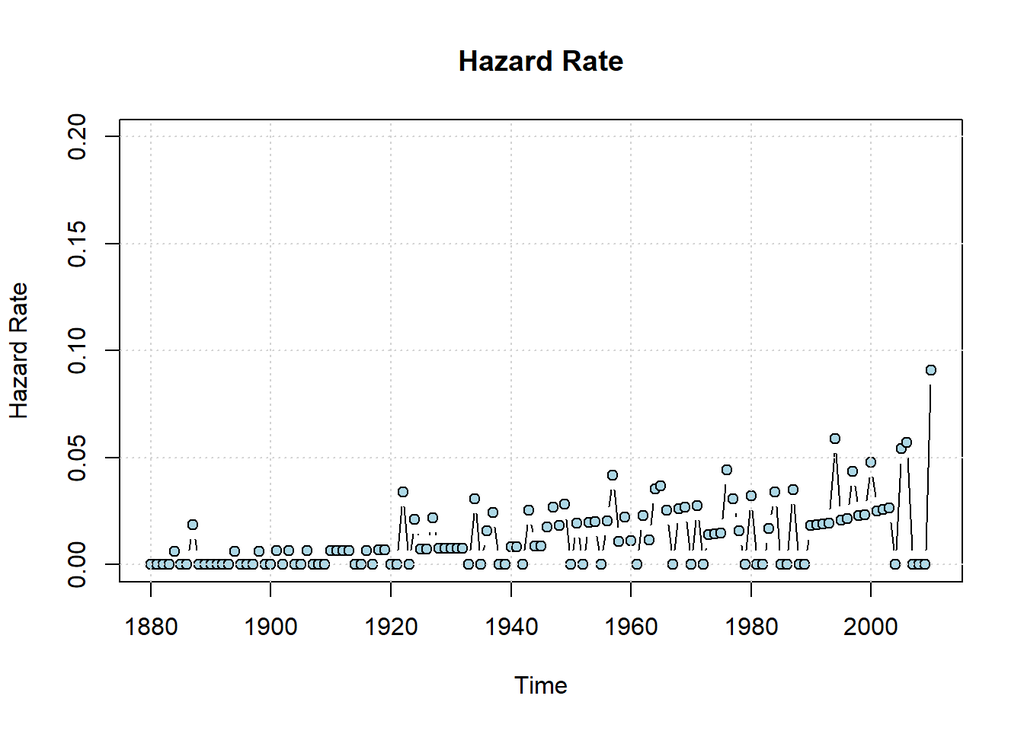

```r
plot_hazard(diffnet_proximity_socins, ylim=c(0,0.2))
```

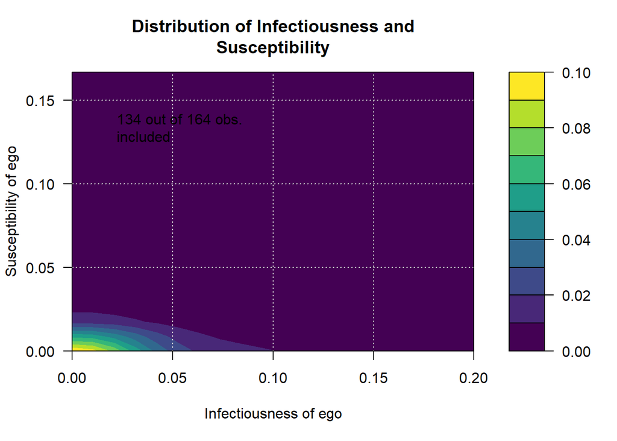

```r
plot_infectsuscep(diffnet_trade_socins, logscale = F)
```

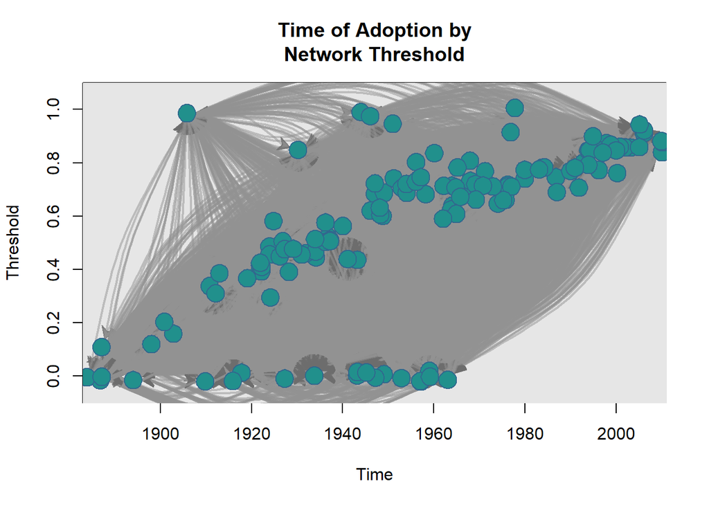

```r
# network threshold: required proportion or number of neighbors that leads you to adopt
plot_threshold(diffnet_trade_socins, undirected = FALSE, vertex.size = 1/5)
```

```r
# ---------------------------------------------
# --- Calculate the  corrected standard errors
# --- the cultural spheres network
# ---------------------------------------------

# Standard error correction: Huber-White standard errors are calculated AFTER the model
# and used to re-calculate the significance

# step 1: calculate corrected standard errors and save output as an object:


m1 <- lmtest::coeftest(model1, vcov = vcovCL(model1, type="HC3", cluster =~ cluster_id))
# unclear error taking place here

m2 <- lmtest::coeftest(model2, vcov = vcovCL(model2, type="HC3", cluster=~ cluster_id))

m3 <- lmtest::coeftest(model3, vcov = vcovCL(model3, type="HC3", cluster=~ cluster_id))

m4 <- lmtest::coeftest(model1_socins, vcov = vcovCL(model1_socins, type="HC3", cluster=~ cluster_id))

m5 <- lmtest::coeftest(model2_socins, vcov = vcovCL(model2_socins, type="HC3", cluster=~ cluster_id))

m6 <- lmtest::coeftest(model3_socins, vcov = vcovCL(model3_socins, type="HC3", cluster=~ cluster_id))


# step 2: run stargazer3 with the following specification:

# 1. odds.ratios = T

# 2. stargazer3(list(m1, m2)...) this is the output of the coeftest function with the corrected
# standard erors!! NOT THE GLM OUTPUT !!

# 3. origin_model: GLM output. This is nessesary to add the model fit statistics to the table.


# BEWARE of the covariate label order!! All your models need the independent variables
# in the same order. If you have multiple models, add the ALL independent variable names to the function call below under covariate.labels!!
# If one model has less variables, this space will be empty only for that model.

# cheatsheets for starger modification: https://www.jakeruss.com/cheatsheets/stargazer/
# these work with stargazer 3 as well.

# change the title, the dep.var.labels and the covariate.labels accordingly

stargazer3(list(m1, m2, m3, m4, m5, m6), odds.ratios = T, origin_model = list(model1, model2, model3, model1_socins, model2_socins, model3_socins), type = "text", se = list(NA, NA, NA, NA, NA, NA),
           title = "Diffusion of Work-Injury Laws, 164 Countries, 1880-2010",
           column.labels=c("------", "First Law", "------", "--", "First Social Insurance", "--"),
          covariate.labels=c("(1880-1902)",
                             "(1903-1928)",
                             "(1929-1954)",
                             "(1955-1979)",
                             "(1980-2010)",
                             "State Founded (last 4 years)",
                             "Network Exposure: Culture (t-1)",
                             "Network Exposure: Colonial",
                             "Network Exposure: Trade (t-1)",
                             "Network Exposrue: Spatial Proximity",
                             "GDPpc 10k USD",
                             "Democratization"
                             ),
          #add.lines = list(c("Countries", length(unique(diff_data$id)), length(unique(diff_data$id)), length(unique(diff_data$id)), length(unique(diff_data$id)), length(unique(diff_data$id)), length(unique(diff_data$id)))),
           out="results/models_final2.htm")
```

```
##
## Diffusion of Work-Injury Laws, 164 Countries, 1880-2010
## =========================================================================================================
##                                                              Dependent variable:
##                                     ---------------------------------------------------------------------
##
##                                      ------   First Law  ------     --    First Social Insurance    --
##                                        (1)       (2)      (3)      (4)             (5)             (6)
## ---------------------------------------------------------------------------------------------------------
## (1880-1902)                         0.003***  0.003***  0.003*** 0.002***        0.002***        0.002***
##
##
## (1903-1928)                         0.007***  0.007***  0.006*** 0.003***        0.003***        0.003***
##
##
## (1929-1954)                         0.003***  0.003***  0.002*** 0.003***        0.003***        0.002***
##
##
## (1955-1979)                         0.002***  0.002***  0.001*** 0.002***        0.001***        0.001***
##
##
## (1980-2010)                         0.002***  0.002***  0.001*** 0.001***        0.001***        0.001***
##
##
## State Founded (last 4 years)                   2.093*    2.169*                  3.390***        3.511***
##
##
## Network Exposure: Culture (t-1)     67.824*** 62.805***  6.114    7.010          11.382+          1.665
##
##
## Network Exposure: Colonial            1.029     1.060    0.886   6.783***        6.564***        5.297***
##
##
## Network Exposure: Trade (t-1)                           24.756*                                  16.238*
##
##
## Network Exposrue: Spatial Proximity   0.986     0.979    0.997    0.911           0.925           0.909
##
##
## GDPpc 10k USD                       1.280***  1.251***  1.252*** 1.170***        1.146***        1.155***
##
##
## ---------------------------------------------------------------------------------------------------------
## Observations                          7766      7766      7766    12162           12162           12162
## Log Likelihood                      -650.477  -647.807  -643.481 -649.725        -639.206        -636.391
## Akaike Inf. Crit.                   1318.955  1315.614  1308.962 1317.45         1298.413        1294.781
## =========================================================================================================
## Note:                                                   + p < 0.1; * p < 0.05; ** p < 0.01; *** p < 0.001
```

```r
# ---------------------------------------------
# --- some functions of netdiffuseR, here for
# --- the cultural spheres network
# ---------------------------------------------

Tbl1 <- as.data.frame(read_html("results/models_final2.htm") %>% html_table(fill=TRUE))

Tbl1 <- Tbl1[Tbl1$X7 != "",]

write.csv(Tbl1, file = "results/Tbl1.csv")
```

### Sensitivity Analysis

Colonial Legacies have an influence that, after the colony ends is essentially constant when colonies become independent.

Thus, the influence of a previous colony that has already ended at that time becomes smaller proportionally to the currently existing colony. When the country then becomes completely independent, the influence no longer differs proportionally from each other. It is thus frozen in its strength.

Colonial legacies have an overall declining strength on the diffusion process. Thus, we calculated a non_normalized version of exposure. Influence of current and past colonies is still weighted and exposure calculated proportionally. However, exposure is constantly declining with more time after independence. Furthermore, we create a situation in which exposure can be larger than 1, depending on the weights of the network ties.

Then we re-run our main models with this variable included.

```r
model3_sens2 <- glm(adopted ~
                + t0_22
              + t23_48
              + t49_74
              + t75_99
              + t100_130
              + existence
              + lag_w_expo_culture
              + non_normalized_w_expo_colony
              + lag_w_expo_trade
              + lag_w_expo_proximity
              + gdp10000
              + regime
              + 0,
              dat    = diff_data,
              subset = (per <= toa),
              family = binomial(link="logit"))


model3_socins_sens2 <- glm(adopted ~
                + t0_22
              + t23_48
              + t49_74
              + t75_99
              + t100_130
              + existence
              + lag_w_expo_culture
              + non_normalized_w_expo_colony
              + lag_w_expo_trade
              + lag_w_expo_proximity
              + gdp10000
              + regime
              + 0,
              dat    = diff_data_socins,
              subset = (per <= toa),
              family = binomial(link="logit"))
#summary(model2)
#exp(coef(model2))
stargazer(model3_sens2,model3_socins_sens2,
          type = "text",
          title = "Discrete Time Hazard/Diffusion Models of /nWork-Injury Law, 1880-2010 in 152 countries",
          out = "results/Tbl_sens_non.htm")
```

```
##
## Discrete Time Hazard/Diffusion Models of /nWork-Injury Law, 1880-2010 in 152 countries
## =========================================================
##                                  Dependent variable:
##                              ----------------------------
##                                        adopted
##                                   (1)            (2)
## ---------------------------------------------------------
## t0_22                          -5.802***      -6.400***
##                                 (0.279)        (0.383)
##
## t23_48                         -5.000***      -5.765***
##                                 (0.306)        (0.282)
##
## t49_74                         -5.949***      -5.653***
##                                 (0.650)        (0.510)
##
## t75_99                         -6.579***      -6.038***
##                                 (0.823)        (0.860)
##
## t100_130                       -6.610***      -6.374***
##                                 (0.940)        (1.144)
##
## existence                       0.779***      1.284***
##                                 (0.298)        (0.241)
##
## lag_w_expo_culture               2.316*         1.575
##                                 (1.250)        (1.613)
##
## non_normalized_w_expo_colony     -0.007        -0.017
##                                 (0.009)        (0.012)
##
## lag_w_expo_trade                 -0.125       1.635***
##                                 (0.231)        (0.377)
##
## lag_w_expo_proximity            3.446***       2.989**
##                                 (1.114)        (1.168)
##
## gdp10000                         0.0003        -0.099
##                                 (0.061)        (0.104)
##
## regime                          0.206***      0.129***
##                                 (0.056)        (0.040)
##
## ---------------------------------------------------------
## Observations                     7,766         12,162
## Log Likelihood                  -643.114      -635.429
## Akaike Inf. Crit.              1,310.227      1,294.858
## =========================================================
## Note:                         *p<0.1; **p<0.05; ***p<0.01
```